# 2016 Election Analysis with a focus on machine learning

### by Ruben Olmos

```r
library(dplyr)
library(readr)
library(kableExtra)
library(ggplot2)
library(maps)
library(tidyr)
library(tidyverse)
library(cluster)
library(factoextra)
library(dendextend)
library(ROCR)
library(glmnet)
library(caret)
library(tree)
library(maptree)
library(ggridges)
library(viridis)
library(hrbrthemes)
```

## Introduction and Background

Predicting Voter behavior is a very difficult task that takes into consideration lots of variables that may change quickly, also known as "chaos", skewing your results.Polls are essential to voter behavior predictions, but only if they are done correctly with random sampling and large sample sizes. In addition, you are relying on polls that are at risk of bias with low response rates, inaccurate polling, and that they do not meausure voter turnout. Another reason voter behavior prediction is hard is because by the time you complete your analysis, the variables and their relations to each other may have already changed. This can lead to a completely different result than what's expected, misleading the audience. This is espcially crucial to Campaign leaders who need to comprehend what areas they need to focus on as their time is extremely valuable. Lastly, how infrequent elections occur makes it difficult for statisticians to be able to practice and perfect models to accurately predict elections. Occurring every 4 years with, about 1 year of strong campaigning, it's hard to collect data that will accurately portray how election night will go.

However despite all the implications of complications of predicition of election results there were some methods whose predictions of results fell very close to the actual ones. In particular methods of prediction used by Nate Silver provided predictions that fell much closer to the actual results then other methods. Silver was able to model voting behavior and much more correctly predict the election result for all 50 states compared to other methods. He utilized hierarchical modeling in order to take into account and analzye the state and national level voting together. He modeled an observed variable of the intended voting behavior in each state which he then used in order to predict the voting results. What made his model stand out from others was that when analyzing poll percentages, actual percentage + the house effect + sampling variation = poll percentage, he utilized a different approach in calculating the probability when "more variation is less likely" to determine which actual percentage has the greatest probability. Rather than examining the maximum probability, Silver calculated the porbability of support for each day and then use the model for the next day to ask what is the probability that support changed from x% to x%. He achieved this by using Bayes' Theorem and graph theory to determine new probabilities of each level of support. With his probabilities of each level of support, he was able to incorporate hierarchical modeling to produce predictions for each level of estimated support on the state and national level on any day leading up to the election.

So what went wrong with the prediction results in 2016 that placed Clinton as a clear favorite? The inaccurate predictions can be attributed to poor polling, misinterpretations and mediocre analysis, and weak election models. In 2016, there was inadequate state polling that were relied on in order to develop models or create prediction forecasts. Because of this, we saw a sweep of all national polls missing in the same direction. Weak election models are also believed to be of blame as it could've caused some forecasting erros as there are so many variables and small changes that can result in big changes. In order to ensure we have better predictions in the future I believe that polling has to be a top priority in that they are correctly receiving data with random sampling, large sample sizes, paying extra attention to swing states in making sure those models are correct, and develop methods to help predict voter turnout as well as having an adequate turnout on election day. Analysis on the weights of certain factors, such as if the candidate is an incumbent, would also be helpful such that statisticians would be able to develop models that accurately portray voter behavior change.

```r
election.raw <- read_delim("election/election.csv", delim = ",") %>% mutate(candidate=as.factor(candidate))


census_meta <- read_delim("census/metadata.csv", delim = ";", col_names = FALSE)
census <- read_delim("census/census.csv", delim = ",")
```

## Description of Data

The Data that we are running an analysis is such that each observation consists of five main characterstics:

**1**.county: the name of the county where the voting was done  
**2**.fips: fips also know as the Federal Information Processing Standard Publication 6-4(FIPS 6-4) is a five digit  
Federal Information Processing Standards code which uniquely identified counties.The five-digit code uses the two digits of FIPS state code followed by the three digits of the county code within the state.  
**3**.candidate: the candidate name of the candidate that was voted for in that particular county  
**4**.state: the state abbreviation of the state where the county is located and where the voting took place.  
**5**.votes: the number of times that a candidate was voted for in that county

Each observation is expressed as a row in a table an each characteristic is set as a column. We can glimpse the data taking for example *Los Angeles* county.

```r
kable(election.raw %>% filter(county == "Los Angeles County"))  %>% kable_styling(bootstrap_options = c("striped", "hover", "condensed", "responsive"), full_width=FALSE)
```

```
<table class="table table-striped table-hover table-condensed table-responsive" style="width: auto !important; margin-left: auto; margin-right: auto;">
 <thead>
  <tr>
   <th style="text-align:left;"> county </th>
   <th style="text-align:left;"> fips </th>
   <th style="text-align:left;"> candidate </th>
   <th style="text-align:left;"> state </th>
   <th style="text-align:right;"> votes </th>
  </tr>
 </thead>
<tbody>
  <tr>
   <td style="text-align:left;"> Los Angeles County </td>
   <td style="text-align:left;"> 6037 </td>
   <td style="text-align:left;"> Hillary Clinton </td>
   <td style="text-align:left;"> CA </td>
   <td style="text-align:right;"> 2464364 </td>
  </tr>
  <tr>
   <td style="text-align:left;"> Los Angeles County </td>
   <td style="text-align:left;"> 6037 </td>
   <td style="text-align:left;"> Donald Trump </td>
   <td style="text-align:left;"> CA </td>
   <td style="text-align:right;"> 769743 </td>
  </tr>
  <tr>
   <td style="text-align:left;"> Los Angeles County </td>
   <td style="text-align:left;"> 6037 </td>
   <td style="text-align:left;"> Gary Johnson </td>
   <td style="text-align:left;"> CA </td>
   <td style="text-align:right;"> 88968 </td>
  </tr>
  <tr>
   <td style="text-align:left;"> Los Angeles County </td>
   <td style="text-align:left;"> 6037 </td>
   <td style="text-align:left;"> Jill Stein </td>
   <td style="text-align:left;"> CA </td>
   <td style="text-align:right;"> 76465 </td>
  </tr>
  <tr>
   <td style="text-align:left;"> Los Angeles County </td>
   <td style="text-align:left;"> 6037 </td>
   <td style="text-align:left;"> Gloria La Riva </td>
   <td style="text-align:left;"> CA </td>
   <td style="text-align:right;"> 21993 </td>
  </tr>
</tbody>
</table>
```

We can observe the number of times that Los Angeles county voted for each presidential candidate, with the candidates identified by name , the votes expressed as integers, the state expressed as an abbreviation and the county identified by fips code. Further there are some rows in our data that are summary rows, these rows contain *NA* values for the county column: There are two types of summary rows:  
**1**.Federal-level summary rows have fips value of *US*.  
**2**.State-level summary rows have names of each states as fips value.

```r
kable(head(election.raw %>% filter(is.na(county)==TRUE),10))  %>% kable_styling(bootstrap_options = c("striped", "hover", "condensed", "responsive"), full_width=FALSE)

kable(tail(election.raw %>% filter(is.na(county)==TRUE),10))  %>% kable_styling(bootstrap_options = c("striped", "hover", "condensed", "responsive"), full_width=FALSE)
```

```
<table class="table table-striped table-hover table-condensed table-responsive" style="width: auto !important; margin-left: auto; margin-right: auto;">
 <thead>
  <tr>
   <th style="text-align:left;"> county </th>
   <th style="text-align:left;"> fips </th>
   <th style="text-align:left;"> candidate </th>
   <th style="text-align:left;"> state </th>
   <th style="text-align:right;"> votes </th>
  </tr>
 </thead>
<tbody>
  <tr>
   <td style="text-align:left;"> NA </td>
   <td style="text-align:left;"> US </td>
   <td style="text-align:left;"> Donald Trump </td>
   <td style="text-align:left;"> US </td>
   <td style="text-align:right;"> 62984825 </td>
  </tr>
  <tr>
   <td style="text-align:left;"> NA </td>
   <td style="text-align:left;"> US </td>
   <td style="text-align:left;"> Hillary Clinton </td>
   <td style="text-align:left;"> US </td>
   <td style="text-align:right;"> 65853516 </td>
  </tr>
  <tr>
   <td style="text-align:left;"> NA </td>
   <td style="text-align:left;"> US </td>
   <td style="text-align:left;"> Gary Johnson </td>
   <td style="text-align:left;"> US </td>
   <td style="text-align:right;"> 4489221 </td>
  </tr>
  <tr>
   <td style="text-align:left;"> NA </td>
   <td style="text-align:left;"> US </td>
   <td style="text-align:left;"> Jill Stein </td>
   <td style="text-align:left;"> US </td>
   <td style="text-align:right;"> 1429596 </td>
  </tr>
  <tr>
```

[output cut: 28 more lines]

```
   <td style="text-align:left;"> NA </td>
   <td style="text-align:left;"> US </td>
   <td style="text-align:left;"> None of these candidates </td>
   <td style="text-align:left;"> US </td>
   <td style="text-align:right;"> 28863 </td>
  </tr>
  <tr>
   <td style="text-align:left;"> NA </td>
   <td style="text-align:left;"> US </td>
   <td style="text-align:left;"> Richard Duncan </td>
   <td style="text-align:left;"> US </td>
   <td style="text-align:right;"> 24235 </td>
  </tr>
</tbody>
</table>
```

```
<table class="table table-striped table-hover table-condensed table-responsive" style="width: auto !important; margin-left: auto; margin-right: auto;">
 <thead>
  <tr>
   <th style="text-align:left;"> county </th>
   <th style="text-align:left;"> fips </th>
   <th style="text-align:left;"> candidate </th>
   <th style="text-align:left;"> state </th>
   <th style="text-align:right;"> votes </th>
  </tr>
 </thead>
<tbody>
  <tr>
   <td style="text-align:left;"> NA </td>
   <td style="text-align:left;"> VT </td>
   <td style="text-align:left;"> Gary Johnson </td>
   <td style="text-align:left;"> VT </td>
   <td style="text-align:right;"> 10078 </td>
  </tr>
  <tr>
   <td style="text-align:left;"> NA </td>
   <td style="text-align:left;"> VT </td>
   <td style="text-align:left;"> Jill Stein </td>
   <td style="text-align:left;"> VT </td>
   <td style="text-align:right;"> 6758 </td>
  </tr>
  <tr>
   <td style="text-align:left;"> NA </td>
   <td style="text-align:left;"> VT </td>
   <td style="text-align:left;"> Rocky De La Fuente </td>
   <td style="text-align:left;"> VT </td>
   <td style="text-align:right;"> 1063 </td>
  </tr>
  <tr>
   <td style="text-align:left;"> NA </td>
   <td style="text-align:left;"> VT </td>
   <td style="text-align:left;"> Gloria La Riva </td>
   <td style="text-align:left;"> VT </td>
   <td style="text-align:right;"> 327 </td>
  </tr>
  <tr>
```

[output cut: 28 more lines]

```
   <td style="text-align:left;"> NA </td>
   <td style="text-align:left;"> WY </td>
   <td style="text-align:left;"> Darrell Castle </td>
   <td style="text-align:left;"> WY </td>
   <td style="text-align:right;"> 2042 </td>
  </tr>
  <tr>
   <td style="text-align:left;"> NA </td>
   <td style="text-align:left;"> WY </td>
   <td style="text-align:left;"> Rocky De La Fuente </td>
   <td style="text-align:left;"> WY </td>
   <td style="text-align:right;"> 709 </td>
  </tr>
</tbody>
</table>
```

Above we can see a glimpse of the summary observations, where if we have a summary for a state level we have an *NA* value for county and the fips column contains the state abbreviation. And if it is a federal summary we have an *NA* value for the county and the fips column contains *US*. That is if an observation is a summary it has a *NA* value for the county and a non-numerical valu for the *fips* code.

## Cleaning the data

Before proceeding with our analysis of the data it is important to deal with any occurrence of faulty or flawed data. A further inspection of the data reveals a problem. It is apparent that for values of 2000 for the fips column, that the respective county is not available, instead in its place is a value of *NA*.

```r
kable(election.raw %>% filter(fips==2000))  %>% kable_styling(bootstrap_options = c("striped", "hover", "condensed", "responsive"), full_width=FALSE)
```

```
<table class="table table-striped table-hover table-condensed table-responsive" style="width: auto !important; margin-left: auto; margin-right: auto;">
 <thead>
  <tr>
   <th style="text-align:left;"> county </th>
   <th style="text-align:left;"> fips </th>
   <th style="text-align:left;"> candidate </th>
   <th style="text-align:left;"> state </th>
   <th style="text-align:right;"> votes </th>
  </tr>
 </thead>
<tbody>
  <tr>
   <td style="text-align:left;"> NA </td>
   <td style="text-align:left;"> 2000 </td>
   <td style="text-align:left;"> Donald Trump </td>
   <td style="text-align:left;"> AK </td>
   <td style="text-align:right;"> 163387 </td>
  </tr>
  <tr>
   <td style="text-align:left;"> NA </td>
   <td style="text-align:left;"> 2000 </td>
   <td style="text-align:left;"> Hillary Clinton </td>
   <td style="text-align:left;"> AK </td>
   <td style="text-align:right;"> 116454 </td>
  </tr>
  <tr>
   <td style="text-align:left;"> NA </td>
   <td style="text-align:left;"> 2000 </td>
   <td style="text-align:left;"> Gary Johnson </td>
   <td style="text-align:left;"> AK </td>
   <td style="text-align:right;"> 18725 </td>
  </tr>
  <tr>
   <td style="text-align:left;"> NA </td>
   <td style="text-align:left;"> 2000 </td>
   <td style="text-align:left;"> Jill Stein </td>
   <td style="text-align:left;"> AK </td>
   <td style="text-align:right;"> 5735 </td>
  </tr>
  <tr>
   <td style="text-align:left;"> NA </td>
   <td style="text-align:left;"> 2000 </td>
   <td style="text-align:left;"> Darrell Castle </td>
   <td style="text-align:left;"> AK </td>
   <td style="text-align:right;"> 3866 </td>
  </tr>
  <tr>
   <td style="text-align:left;"> NA </td>
   <td style="text-align:left;"> 2000 </td>
   <td style="text-align:left;"> Rocky De La Fuente </td>
   <td style="text-align:left;"> AK </td>
   <td style="text-align:right;"> 1240 </td>
  </tr>
</tbody>
</table>
```

On first thought it seems that it would seem reasonable to look up the county that corresponds to the fips code of 2000, but looking up the county for the fips code 2000 results in the realization that this code does not exist. On second thought it would seem reasonable that if we had enough information on the state of AK that we can deduce to which county these values pertain to so we inspect the available date for AK:

```r
kable(election.raw %>% filter(state=='AK'))  %>% kable_styling(bootstrap_options = c("striped", "hover", "condensed", "responsive"), full_width=FALSE)
```

```
<table class="table table-striped table-hover table-condensed table-responsive" style="width: auto !important; margin-left: auto; margin-right: auto;">
 <thead>
  <tr>
   <th style="text-align:left;"> county </th>
   <th style="text-align:left;"> fips </th>
   <th style="text-align:left;"> candidate </th>
   <th style="text-align:left;"> state </th>
   <th style="text-align:right;"> votes </th>
  </tr>
 </thead>
<tbody>
  <tr>
   <td style="text-align:left;"> NA </td>
   <td style="text-align:left;"> AK </td>
   <td style="text-align:left;"> Donald Trump </td>
   <td style="text-align:left;"> AK </td>
   <td style="text-align:right;"> 163387 </td>
  </tr>
  <tr>
   <td style="text-align:left;"> NA </td>
   <td style="text-align:left;"> AK </td>
   <td style="text-align:left;"> Hillary Clinton </td>
   <td style="text-align:left;"> AK </td>
   <td style="text-align:right;"> 116454 </td>
  </tr>
  <tr>
   <td style="text-align:left;"> NA </td>
   <td style="text-align:left;"> AK </td>
   <td style="text-align:left;"> Gary Johnson </td>
   <td style="text-align:left;"> AK </td>
   <td style="text-align:right;"> 18725 </td>
  </tr>
  <tr>
   <td style="text-align:left;"> NA </td>
   <td style="text-align:left;"> AK </td>
   <td style="text-align:left;"> Jill Stein </td>
   <td style="text-align:left;"> AK </td>
   <td style="text-align:right;"> 5735 </td>
  </tr>
  <tr>
```

[output cut: 42 more lines]

```
   <td style="text-align:left;"> NA </td>
   <td style="text-align:left;"> 2000 </td>
   <td style="text-align:left;"> Darrell Castle </td>
   <td style="text-align:left;"> AK </td>
   <td style="text-align:right;"> 3866 </td>
  </tr>
  <tr>
   <td style="text-align:left;"> NA </td>
   <td style="text-align:left;"> 2000 </td>
   <td style="text-align:left;"> Rocky De La Fuente </td>
   <td style="text-align:left;"> AK </td>
   <td style="text-align:right;"> 1240 </td>
  </tr>
</tbody>
</table>
```

We observe that the only available data that we have for Alaska is the state summary and the data for where the county code is 2000. With this information we cannot reasonably deduce to which county this data belongs to. Therefore the best practice is to remove the data where the county code is 2000.

```r
dim(election.raw)
```

1. 18351

2. 5

The dimensions of our data before removing are 18351 rows and 5 columns.

```r
election.raw<-election.raw[!(election.raw$fips==2000),]
dim(election.raw)
```

1. 18345

2. 5

After removing the observations where the county code is 2000 the dimensions for the data are 18345 rows and 5 columns.

For the purposes of our analysis it is practical to remove federal and state level summaries of election voting. These will interfere with the analysis that we want to conduct. Our current dimensions inclusive of state and federal summaries are 18345 rows and 5 columns.

```r
election_federal <- election.raw %>% filter(fips == 'US' & is.na(county))

election_state <- election.raw %>% filter(fips != "US" & is.na(county))

election <- election.raw %>% filter(fips != "US" & as.character(fips) != as.character(state))

election.raw<-election.raw[!(is.na(election.raw$county)==TRUE),]
dim(election.raw)
```

1. 18011

2. 5

After removing all summaries(federal and state) the dimensions of our data are now 18011 rows and 5 columns.

## Initial visual analysis of votes per candidate

In the 2016 election there were 31 candidates for the presidential election. We can run an initial visualization on the votes received by each the candidates, to get a senese of the outcome of the election and the distribution of votes.

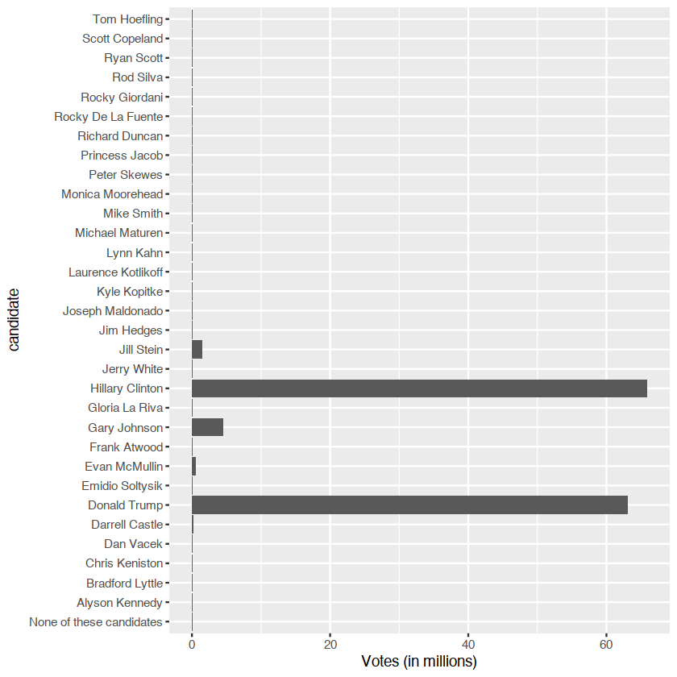

```r
ggplot(election_federal, aes(x = candidate, y = votes/1000000)) +
  geom_bar(stat = "identity") + coord_flip() + scale_y_continuous() + ylab("Votes (in millions)")
```

## Creating columns for winning candidate by county and by state

For simplicity of analysis we create county_winner and state_winner by taking the candidate with the highest proportion of votes.To create county_winner we start with election, group by fips, compute total votes, and create variable pct = votes/total. Then choose the highest row using top_n. We follow a similar approach with state_winner arriving at an aggregated column containing the winner for every state.

```r
county_group <- group_by(election, fips)
county_total <- summarize(county_group, total = sum(votes))
county.group <- left_join(county_group, county_total, by = "fips")
county_pct <- mutate(county.group, pct = votes/total)
county_winner <- top_n(county_pct, n =1)

state_group <- group_by(election_state, state)
state_total <- summarize(state_group, total = sum(votes))
state.group <- left_join(state_group, state_total, by = "state")
state_pct <- mutate(state.group, pct = votes/total)
state_winner <- top_n(state_pct, n= 1)
```

## Visualizing State and County Election Outcomes on U.S Map

Visualization is crucial for gaining insight and intuition during data mining. We will map our data onto map in order to have visual representations of the results on the county level and on the state levels.

The R package ggplot2 can be used to draw maps and we make use of it to create a map visualization of our data.

The variable states contain information to draw white polygons, and fill-colors are determined by region. We great an initial visualization of the U.S counties and create a visual map of the counties colored by the counties by using counties = map_data("county").

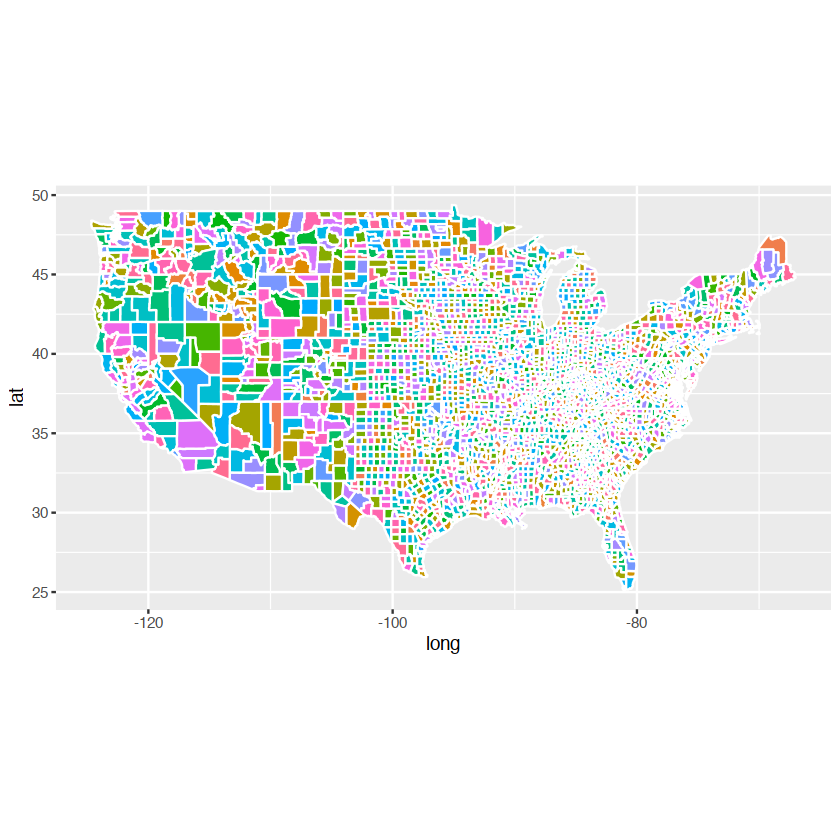

```r
counties=map_data("county")
ggplot(data = counties) +
  geom_polygon(aes(x = long, y = lat, fill = subregion, group = group), color = "white") +
  coord_fixed(1.3) +
  guides(fill=FALSE)  # color legend is unnecessary and takes too long
```

## Visualizing the results by state

Now we color the map by the winning candidate for each state. We'll combine the two datasets based on state name. However, the state names are in different formats in the two tables: e.g. AZ vs. arizona. Before using left_join(), we create a common column by creating a new column for states named fips=state.abb[match(states$region, casefold(state.name) )]. We then combine states variable and state_winner we created earlier using left_join(). A call to left_join() takes all the values from the first table and looks for matches in the second table. If it finds a match, it adds the data from the second table; if not, it adds missing values. After doing this we visualize our results:

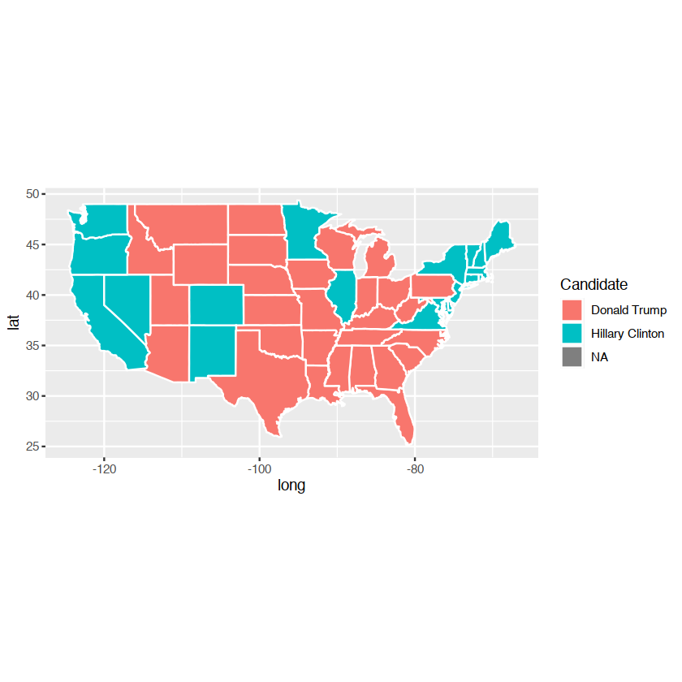

```r
states <- map_data("state")
states <- states %>%
  mutate(fips=state.abb[match(states$region, casefold(state.name) )])
states <- left_join(states, state_winner, by="fips")
ggplot(data = states) +
  geom_polygon(aes(x = long, y = lat, fill = candidate, group = group),colour="white") +
  coord_fixed(1.3)+
  guides(fill=guide_legend(title="Candidate"))
```

Where a red signifies that Donald Trump won that state and where a blue signifies that Hilary Clinton won.

## Visualizing the results by County

The variable county does not have fips column. So we will create one by pooling information from maps::county.fips. We split the polyname column to region and subregion,use left_join() combine county.fips into county and left_join() previously created variable county_winner. Finally we visualize the election results on a county level colored by winner for each county.

```
Warning message:
“Use of `county_new$candidate` is discouraged. Use `candidate` instead.”
```

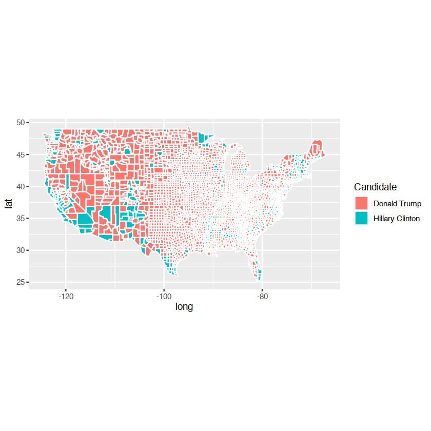

```r
county_split=separate(maps::county.fips,polyname,c("region", "subregion"),sep="," )

county_combined=left_join(county_split,counties,by=c("region", "subregion"))
county_combined$fips=as.factor(county_combined$fips)
county_new=left_join(county_combined,county_winner)

ggplot(data = county_new) +
  geom_polygon(aes(x = long, y = lat, fill = county_new$candidate, group = group),colour="white" ) +
  coord_fixed(1.3)+
  guides(fill=guide_legend(title="Candidate"))
```

Where a red signifies that Donald Trump won that state and where a blue signifies that Hilary Clinton won.

## Further Visual Analysis into demographics of interest

It would be interesting to visualize the poverty percentage by state, given that the United States holds very varied views on social-economic systems that are often thought to be linked to economic status of groups. We can then visualize the percentage of povery for each state.

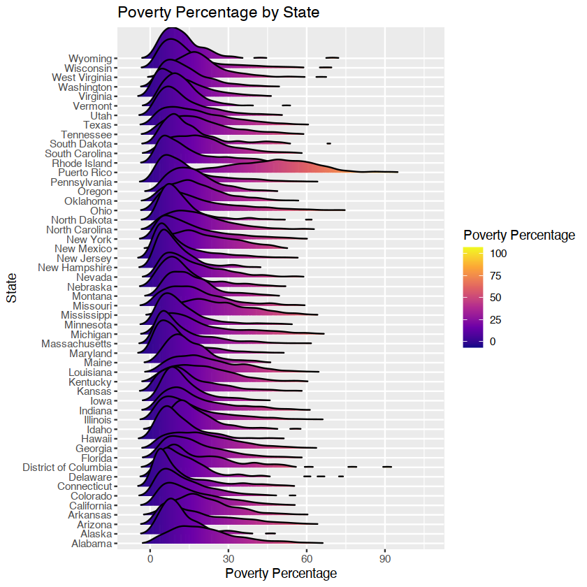

```r
ggplot(data = census, aes(y = as.factor(State), x = Poverty, fill = ..x..)) +
    geom_density_ridges_gradient(scale = 4, rel_min_height = 0.01) +
    scale_fill_viridis_c(name = "Poverty Percentage", option = "C") +
    ggtitle('Poverty Percentage by State') +
    ylab("State") + xlab("Poverty Percentage")
```

This ridgeplot illustrates the poverty percentage of each state as most states hover around the range of 8%-12%.

It would also be interesting to visualize the percentage of the black population in each state given that social issues surrounding the black community have gained a greater amount of political traction and that this issues are commonly associated with social ideas on which political ideologies differ greatly.

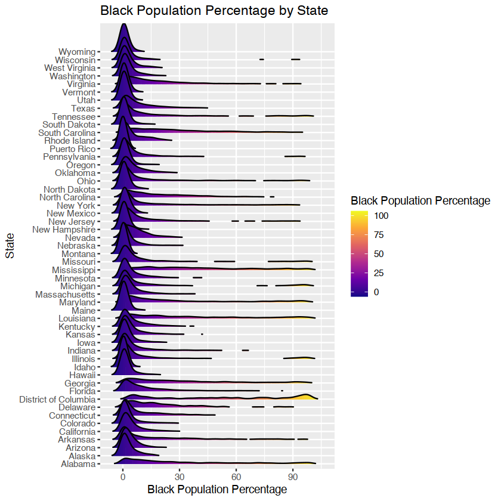

```r
ggplot(data = census, aes(y = as.factor(State), x = Black, fill = ..x..)) +
    geom_density_ridges_gradient(scale = 4, rel_min_height = 0.01) +
    scale_fill_viridis_c(name = "Black Population Percentage", option = "C") +
    ggtitle('Black Population Percentage by State') +
    ylab("State") + xlab("Black Population Percentage")
```

This plot shows the Black population percentage per state as the vast majority of states possess a very low percentage under 5%.

It would also be interesting to see a visual representation of the white population given that this is the predominant population in the United States, and in which a great deal of the election results are attributed to despite the amount of variance that is present in this demographic.

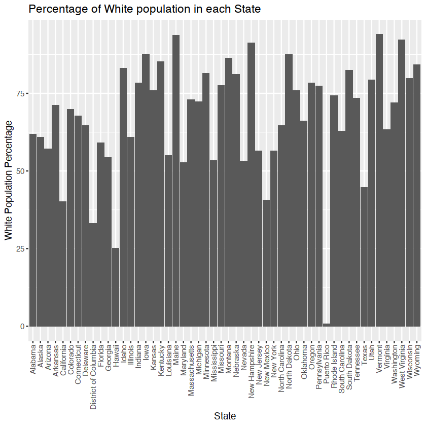

```r
census1=census %>% group_by(State) %>% summarise(White_Pct=mean(White,na.rm=TRUE))
 ggplot(census1,aes(x=State,y=White_Pct)) +
   geom_bar(stat="identity")+
   theme(axis.text.x = element_text(angle = 90, vjust = 0.5, hjust=1)) +
   ggtitle("Percentage of White population in each State") +
   ylab("White Population Percentage")
```

We can observe that in the 46 states, the White population comprises of the majority population in regards to race/ethnicity.

## Cleaning and preparing Census data for use

The census data contains high resolution information (more fine-grained than county-level).We will aggregate the information into county-level data by computing TotalPop-weighted average of each attributes for each county. We can accomplish this in accordance to our analysis by first cleaning the census data census.del starting with the attribute census by filter out any rows with missing values. We then convert {Men, Employed, Citizen} attributes to percentages (meta data seems to be inaccurate) and compute Minority attribute by combining {Hispanic, Black, Native, Asian, Pacific} and after creating Minority we remove {Walk, PublicWork, Construction}.

Now we create census.subct starting with census.del from above and group_by() two attributes {State, County}, use add_tally() to compute CountyTotal and compute the weight by TotalPop/CountyTotal.

Finally we create census.ct starting with census.subct and use summarize_at() to compute weighted sum.

```r
census.del <- na.omit(census) %>% mutate(Men = Men/TotalPop*100,
              Employed = Employed/TotalPop*100,
              Citizen = Citizen/TotalPop*100,
              Minority = Hispanic+Black+Native+Asian+Pacific) %>%
select(-Women, -Hispanic, -Native, -Black, -Asian, -Pacific, -Construction,-Walk, -PublicWork) #census.del <- census.del[,c(1:6,29,7:28)] # reordering (want minority next to white)







census.subct<-census.del%>%
  group_by(State,County) %>%
  add_tally(TotalPop) %>%
  mutate(CountyTotal=n)%>%
  mutate(Weight=TotalPop/CountyTotal) %>%
  select(-n)


census.ct <- census.subct %>% summarize_at(vars(  Men, White, Citizen, Income, IncomeErr, IncomePerCap,   IncomePerCapErr, Poverty, ChildPoverty, Professional, Service, Office,  Production, Drive, Carpool, Transit, OtherTransp, WorkAtHome, MeanCommute, Employed, PrivateWork, SelfEmployed, FamilyWork, Unemployment, Minority, CountyTotal),  funs(weighted.mean(., Weight)))
```

Observing the first few rows of census.ct this is what our data looks like.

```r
kable(head(census.ct[,1:7])) %>% kable_classic(
  lightable_options = "striped",
  html_font = "Arial")
kable(head(census.ct[,8:14])) %>% kable_classic(
  lightable_options = "striped",
  html_font = "Arial")
kable(head(census.ct[,15:21])) %>% kable_classic(
  lightable_options = "striped",
  html_font = "Arial")
kable(head(census.ct[,22:27])) %>% kable_classic(
  lightable_options = "striped",
  html_font = "Arial")
```

```
<table class=" lightable-classic lightable-striped" style="font-family: Arial; margin-left: auto; margin-right: auto;">
 <thead>
  <tr>
   <th style="text-align:left;"> State </th>
   <th style="text-align:left;"> County </th>
   <th style="text-align:right;"> Men </th>
   <th style="text-align:right;"> White </th>
   <th style="text-align:right;"> Citizen </th>
   <th style="text-align:right;"> Income </th>
   <th style="text-align:right;"> IncomeErr </th>
  </tr>
 </thead>
<tbody>
  <tr>
   <td style="text-align:left;"> Alabama </td>
   <td style="text-align:left;"> Autauga </td>
   <td style="text-align:right;"> 48.43266 </td>
   <td style="text-align:right;"> 75.78823 </td>
   <td style="text-align:right;"> 73.74912 </td>
   <td style="text-align:right;"> 51696.29 </td>
   <td style="text-align:right;"> 7771.009 </td>
  </tr>
  <tr>
   <td style="text-align:left;"> Alabama </td>
   <td style="text-align:left;"> Baldwin </td>
   <td style="text-align:right;"> 48.84866 </td>
   <td style="text-align:right;"> 83.10262 </td>
   <td style="text-align:right;"> 75.69406 </td>
   <td style="text-align:right;"> 51074.36 </td>
   <td style="text-align:right;"> 8745.050 </td>
  </tr>
  <tr>
   <td style="text-align:left;"> Alabama </td>
   <td style="text-align:left;"> Barbour </td>
   <td style="text-align:right;"> 53.82816 </td>
   <td style="text-align:right;"> 46.23159 </td>
   <td style="text-align:right;"> 76.91222 </td>
   <td style="text-align:right;"> 32959.30 </td>
   <td style="text-align:right;"> 6031.065 </td>
  </tr>
```

[output cut: 14 more lines]

```
   <td style="text-align:right;"> 73.37550 </td>
   <td style="text-align:right;"> 46237.97 </td>
   <td style="text-align:right;"> 8695.786 </td>
  </tr>
  <tr>
   <td style="text-align:left;"> Alabama </td>
   <td style="text-align:left;"> Bullock </td>
   <td style="text-align:right;"> 53.00618 </td>
   <td style="text-align:right;"> 22.19918 </td>
   <td style="text-align:right;"> 75.45420 </td>
   <td style="text-align:right;"> 33292.69 </td>
   <td style="text-align:right;"> 9000.345 </td>
  </tr>
</tbody>
</table>
```

```
<table class=" lightable-classic lightable-striped" style="font-family: Arial; margin-left: auto; margin-right: auto;">
 <thead>
  <tr>
   <th style="text-align:right;"> IncomePerCap </th>
   <th style="text-align:right;"> IncomePerCapErr </th>
   <th style="text-align:right;"> Poverty </th>
   <th style="text-align:right;"> ChildPoverty </th>
   <th style="text-align:right;"> Professional </th>
   <th style="text-align:right;"> Service </th>
   <th style="text-align:right;"> Office </th>
  </tr>
 </thead>
<tbody>
  <tr>
   <td style="text-align:right;"> 24974.50 </td>
   <td style="text-align:right;"> 3433.674 </td>
   <td style="text-align:right;"> 12.91231 </td>
   <td style="text-align:right;"> 18.70758 </td>
   <td style="text-align:right;"> 32.79097 </td>
   <td style="text-align:right;"> 17.17044 </td>
   <td style="text-align:right;"> 24.28243 </td>
  </tr>
  <tr>
   <td style="text-align:right;"> 27316.84 </td>
   <td style="text-align:right;"> 3803.718 </td>
   <td style="text-align:right;"> 13.42423 </td>
   <td style="text-align:right;"> 19.48431 </td>
   <td style="text-align:right;"> 32.72994 </td>
   <td style="text-align:right;"> 17.95092 </td>
   <td style="text-align:right;"> 27.10439 </td>
  </tr>
  <tr>
   <td style="text-align:right;"> 16824.22 </td>
   <td style="text-align:right;"> 2430.189 </td>
   <td style="text-align:right;"> 26.50563 </td>
   <td style="text-align:right;"> 43.55962 </td>
   <td style="text-align:right;"> 26.12404 </td>
   <td style="text-align:right;"> 16.46343 </td>
   <td style="text-align:right;"> 23.27878 </td>
  </tr>
```

[output cut: 14 more lines]

```
   <td style="text-align:right;"> 28.52930 </td>
   <td style="text-align:right;"> 13.94252 </td>
   <td style="text-align:right;"> 23.83692 </td>
  </tr>
  <tr>
   <td style="text-align:right;"> 17579.57 </td>
   <td style="text-align:right;"> 3110.645 </td>
   <td style="text-align:right;"> 24.50260 </td>
   <td style="text-align:right;"> 37.29116 </td>
   <td style="text-align:right;"> 19.55253 </td>
   <td style="text-align:right;"> 14.92420 </td>
   <td style="text-align:right;"> 20.17051 </td>
  </tr>
</tbody>
</table>
```

```
<table class=" lightable-classic lightable-striped" style="font-family: Arial; margin-left: auto; margin-right: auto;">
 <thead>
  <tr>
   <th style="text-align:right;"> Production </th>
   <th style="text-align:right;"> Drive </th>
   <th style="text-align:right;"> Carpool </th>
   <th style="text-align:right;"> Transit </th>
   <th style="text-align:right;"> OtherTransp </th>
   <th style="text-align:right;"> WorkAtHome </th>
   <th style="text-align:right;"> MeanCommute </th>
  </tr>
 </thead>
<tbody>
  <tr>
   <td style="text-align:right;"> 17.15713 </td>
   <td style="text-align:right;"> 87.50624 </td>
   <td style="text-align:right;"> 8.781235 </td>
   <td style="text-align:right;"> 0.0952590 </td>
   <td style="text-align:right;"> 1.3059687 </td>
   <td style="text-align:right;"> 1.8356531 </td>
   <td style="text-align:right;"> 26.50016 </td>
  </tr>
  <tr>
   <td style="text-align:right;"> 11.32186 </td>
   <td style="text-align:right;"> 84.59861 </td>
   <td style="text-align:right;"> 8.959078 </td>
   <td style="text-align:right;"> 0.1266209 </td>
   <td style="text-align:right;"> 1.4438000 </td>
   <td style="text-align:right;"> 3.8504774 </td>
   <td style="text-align:right;"> 26.32218 </td>
  </tr>
  <tr>
   <td style="text-align:right;"> 23.31741 </td>
   <td style="text-align:right;"> 83.33021 </td>
   <td style="text-align:right;"> 11.056609 </td>
   <td style="text-align:right;"> 0.4954032 </td>
   <td style="text-align:right;"> 1.6217251 </td>
   <td style="text-align:right;"> 1.5019456 </td>
   <td style="text-align:right;"> 24.51828 </td>
  </tr>
```

[output cut: 14 more lines]

```
   <td style="text-align:right;"> 0.4199411 </td>
   <td style="text-align:right;"> 2.2654133 </td>
   <td style="text-align:right;"> 34.84489 </td>
  </tr>
  <tr>
   <td style="text-align:right;"> 25.73547 </td>
   <td style="text-align:right;"> 74.77277 </td>
   <td style="text-align:right;"> 14.839127 </td>
   <td style="text-align:right;"> 0.7732160 </td>
   <td style="text-align:right;"> 1.8238247 </td>
   <td style="text-align:right;"> 3.0998783 </td>
   <td style="text-align:right;"> 28.63106 </td>
  </tr>
</tbody>
</table>
```

```
<table class=" lightable-classic lightable-striped" style="font-family: Arial; margin-left: auto; margin-right: auto;">
 <thead>
  <tr>
   <th style="text-align:right;"> Employed </th>
   <th style="text-align:right;"> PrivateWork </th>
   <th style="text-align:right;"> SelfEmployed </th>
   <th style="text-align:right;"> FamilyWork </th>
   <th style="text-align:right;"> Unemployment </th>
   <th style="text-align:right;"> Minority </th>
  </tr>
 </thead>
<tbody>
  <tr>
   <td style="text-align:right;"> 43.43637 </td>
   <td style="text-align:right;"> 73.73649 </td>
   <td style="text-align:right;"> 5.433254 </td>
   <td style="text-align:right;"> 0.0000000 </td>
   <td style="text-align:right;"> 7.733726 </td>
   <td style="text-align:right;"> 22.53687 </td>
  </tr>
  <tr>
   <td style="text-align:right;"> 44.05113 </td>
   <td style="text-align:right;"> 81.28266 </td>
   <td style="text-align:right;"> 5.909353 </td>
   <td style="text-align:right;"> 0.3633269 </td>
   <td style="text-align:right;"> 7.589820 </td>
   <td style="text-align:right;"> 15.21426 </td>
  </tr>
  <tr>
   <td style="text-align:right;"> 31.92113 </td>
   <td style="text-align:right;"> 71.59426 </td>
   <td style="text-align:right;"> 7.149837 </td>
   <td style="text-align:right;"> 0.0897742 </td>
   <td style="text-align:right;"> 17.525557 </td>
   <td style="text-align:right;"> 51.94382 </td>
  </tr>
  <tr>
   <td style="text-align:right;"> 36.69262 </td>
   <td style="text-align:right;"> 76.74385 </td>
   <td style="text-align:right;"> 6.637936 </td>
   <td style="text-align:right;"> 0.3941515 </td>
   <td style="text-align:right;"> 8.163104 </td>
   <td style="text-align:right;"> 24.16597 </td>
  </tr>
  <tr>
   <td style="text-align:right;"> 38.44914 </td>
   <td style="text-align:right;"> 81.82671 </td>
   <td style="text-align:right;"> 4.228716 </td>
   <td style="text-align:right;"> 0.3564928 </td>
   <td style="text-align:right;"> 7.699640 </td>
   <td style="text-align:right;"> 10.59474 </td>
  </tr>
  <tr>
   <td style="text-align:right;"> 36.19592 </td>
   <td style="text-align:right;"> 79.09065 </td>
   <td style="text-align:right;"> 5.273684 </td>
   <td style="text-align:right;"> 0.0000000 </td>
   <td style="text-align:right;"> 17.890026 </td>
   <td style="text-align:right;"> 76.53587 </td>
  </tr>
</tbody>
</table>
```

## Dimensionality reduction

We would like to run the principal component analysis in order to reduce the dimensionality of our data to a basis of attributes that are most likely to characterize and distinguish observations into classifications through the variance of the attributes. We can begin by looking at the variance of our data on the county level and on the sub county leve, before running principal component analysis.

```r
census_var<-data.frame(apply(census.ct[sapply(census.ct,is.numeric)] , 2, var))
subcensus_var<-data.frame(apply(census.subct[sapply(census.subct,is.numeric)],2,var))
names(census_var)[1]<-"County Variance"
names(subcensus_var)[1]<-"Sub-County Variance"
census_var
subcensus_var
```

A data.frame: 26 × 1

|  | County Variance <dbl> |
| --- | --- |
| Men | 5.416023e+00 |
| White | 5.264985e+02 |
| Citizen | 2.782521e+01 |
| Income | 1.871915e+08 |
| IncomeErr | 5.807218e+06 |
| IncomePerCap | 3.804072e+07 |
| IncomePerCapErr | 1.210144e+06 |
| Poverty | 6.931216e+01 |
| ChildPoverty | 1.317339e+02 |
| Professional | 3.993572e+01 |
| Service | 1.360058e+01 |
| Office | 1.022755e+01 |
| Production | 3.300854e+01 |
| Drive | 5.737029e+01 |
| Carpool | 8.508591e+00 |
| Transit | 9.442292e+00 |
| OtherTransp | 2.920815e+00 |
| WorkAtHome | 9.714816e+00 |
| MeanCommute | 3.115353e+01 |
| Employed | 4.796921e+01 |
| PrivateWork | 6.274646e+01 |
| SelfEmployed | 1.531612e+01 |
| FamilyWork | 1.983356e-01 |
| Unemployment | 1.707899e+01 |
| Minority | 5.265263e+02 |
| CountyTotal | 1.010528e+11 |

A data.frame: 28 × 1

|  | Sub-County Variance <dbl> |
| --- | --- |
| TotalPop | 4.359715e+06 |
| Men | 1.636172e+01 |
| White | 9.409886e+02 |
| Citizen | 1.129972e+02 |
| Income | 8.216231e+08 |
| IncomeErr | 3.488153e+07 |
| IncomePerCap | 2.199818e+08 |
| IncomePerCapErr | 8.520643e+06 |
| Poverty | 1.676799e+02 |
| ChildPoverty | 3.651913e+02 |
| Professional | 2.222947e+02 |
| Service | 6.618685e+01 |
| Office | 3.269766e+01 |
| Production | 5.731659e+01 |
| Drive | 2.261628e+02 |
| Carpool | 2.720594e+01 |
| Transit | 1.364397e+02 |
| OtherTransp | 6.305265e+00 |
| WorkAtHome | 1.335178e+01 |
| MeanCommute | 4.809799e+01 |
| Employed | 8.211358e+01 |
| PrivateWork | 6.618434e+01 |
| SelfEmployed | 1.474701e+01 |
| FamilyWork | 2.090834e-01 |
| Unemployment | 3.361937e+01 |
| Minority | 9.335587e+02 |
| CountyTotal | 3.711516e+12 |
| Weight | 9.334002e-03 |

We can then move on to observing the means on the subcounty and on the county level.

```r
meanofcensus.ct<-data.frame(apply(as.matrix(census.ct[, 3:27]), 2, mean))
meanofcensus.subct<-data.frame(apply(as.matrix(census.subct[, 3:27]), 2, mean))
names(meanofcensus.ct)[1]<-"County Means"
names(meanofcensus.subct)[1]<-"Sub-County Means"
meanofcensus.ct
meanofcensus.subct
```

A data.frame: 25 × 1

|  | County Means <dbl> |
| --- | --- |
| Men | 4.995373e+01 |
| White | 7.547990e+01 |
| Citizen | 7.467507e+01 |
| Income | 4.722170e+04 |
| IncomeErr | 7.081758e+03 |
| IncomePerCap | 2.400075e+04 |
| IncomePerCapErr | 3.120460e+03 |
| Poverty | 1.757066e+01 |
| ChildPoverty | 2.383369e+01 |
| Professional | 3.080041e+01 |
| Service | 1.847286e+01 |
| Office | 2.218309e+01 |
| Production | 1.580602e+01 |
| Drive | 7.914627e+01 |
| Carpool | 1.031949e+01 |
| Transit | 9.897334e-01 |
| OtherTransp | 1.625164e+00 |
| WorkAtHome | 4.605074e+00 |
| MeanCommute | 2.331344e+01 |
| Employed | 4.302471e+01 |
| PrivateWork | 7.418303e+01 |
| SelfEmployed | 7.916454e+00 |
| FamilyWork | 2.873302e-01 |
| Unemployment | 8.157064e+00 |
| Minority | 2.266877e+01 |

A data.frame: 25 × 1

|  | Sub-County Means <dbl> |
| --- | --- |
| TotalPop | 4383.554168 |
| Men | 49.104724 |
| White | 62.064004 |
| Citizen | 71.280147 |
| Income | 57259.136318 |
| IncomeErr | 9132.597261 |
| IncomePerCap | 28520.769425 |
| IncomePerCapErr | 3925.600644 |
| Poverty | 16.887969 |
| ChildPoverty | 22.469815 |
| Professional | 34.799592 |
| Service | 19.077035 |
| Office | 23.926241 |
| Production | 12.884780 |
| Drive | 75.711413 |
| Carpool | 9.637483 |
| Transit | 5.440670 |
| OtherTransp | 1.880372 |
| WorkAtHome | 4.322362 |
| MeanCommute | 25.690046 |
| Employed | 45.664335 |
| PrivateWork | 79.006662 |
| SelfEmployed | 6.223640 |
| FamilyWork | 0.170106 |
| Unemployment | 9.003846 |

We can observe the variances of the data and see that they are not all the same, there are some variances that are by orders of magnitude larger than the rest. If we proceed with the reduction of dimensionality without scaling the variables what may happen is that most of the principal component that we observe would be driven by those variables with larger variances. It is then a good idea to scale the variables before running our principal component analysis to reduce the dimensionality of our data. Further centering the data before running principal component can help us avoid possible misleading 1st principal components where it may appear that the the direction of principal component analysis is in one direction but it is in fact in another. The means on the subcounty and county level also seem to be pretty far apart which provides indication that the principal components that result from running PCA may be misleading as mentioned . Therefore for the data at both the county and the sub-county level it is best practice to both center and scale the data. If we have vastly different means then it is good practice to center, the scale controls the standard deviation and it is also good practice to account for large impacts of variance. Now we can run the principal component analysis:

```r
# PCA on county-level data with first two principle components
county_model <- prcomp(subset(census.ct, select = -c(State, County)), center = TRUE, scale = TRUE)
ct.pc <- data.frame(county_model$rotation[, 1:2])

# subcounty PCA with first two principle components.
subct_model <- prcomp(subset(census.subct, select = -c(State, County, TotalPop, Weight)), center = TRUE, scale = TRUE)
subct.pc <- data.frame(subct_model$rotation[, 1:2])

# Grabbing the three features the largest values for PC1 in both county and subcounty models.
sort(abs(county_model$rotation[, 1]), decreasing = TRUE)[1:3]
sort(abs(subct_model$rotation[, 1]), decreasing = TRUE)[1:3]

# Checking the loading vectors for the PCA models.
#data.frame(county_model$rotation[, 1])
#data.frame(subct_model$rotation[, 1])
```

**IncomePerCap**

0.353076716077694

**ChildPoverty**

0.342153045598442

**Poverty**

0.340583243369814

**IncomePerCap**

0.318154894206423

**Professional**

0.306307909270984

**Poverty**

0.304367450642174

## Minimum number of Principal Components and Proportion of Variance Explained

We can determine the number of minimum number of PCs needed to capture 90% of the variance for both the county and sub-county analyses. Further we can visualize the proportion of variance explained (PVE) and cumulative PVE for both county and sub-county analyses as well.

14

15

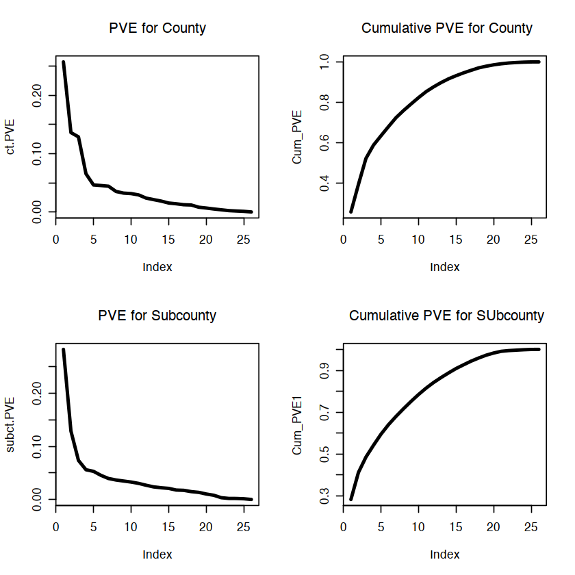

```r
ct.PVE <- county_model$sdev^2/sum(county_model$sdev^2)
# Calculating cumulative PVE for county-level data.
Cum_PVE <- cumsum(ct.PVE)

# Calculating PVE for subcounty-level data.
subct.PVE <- subct_model$sdev^2/sum(subct_model$sdev^2)

# Calculating cumulative PVE for subcounty-level data.
Cum_PVE1 <- cumsum(subct.PVE)

par(mfrow=c(2, 2))
plot(ct.PVE, type="l", lwd=3, main="PVE for County")
plot(Cum_PVE, type="l", lwd=3,main=" Cumulative PVE for County")
plot(subct.PVE, type="l", lwd=3, main="PVE for Subcounty")
plot(Cum_PVE1, type="l", lwd=3,main=" Cumulative PVE for SUbcounty")


# Finding number of principle components to explain at least 90% of the variation for county-level data.
which(Cum_PVE == min(Cum_PVE[Cum_PVE >= .9]))


# Finding number of principle components to explain at least 90% of the variation for subcounty-level data.
which(Cum_PVE1 == min(Cum_PVE1[Cum_PVE1 >= .9]))
```

For county, it takes 14 PC's to capture 90% of the variance.

For sub-county, it takes 15 Pc's to capture 90% of the variance.

## Hierachical clustering with complete linkage: PCA v.s Non-PCA

With census.ct we can perform hierarchical clustering with complete linkage. We first run hierachical clustering without the most significant principal components and then re-run the hierarchical clustering algorithm using the first 5 principal components of ct.pc as inputs instead of the originald features. We do this by cutting our tree to partition the observations into 10 clusters. We can interpret the effectiveness of the methods by assessing which method better placed a random county. In our case we will use San Mateo as an indicator county.

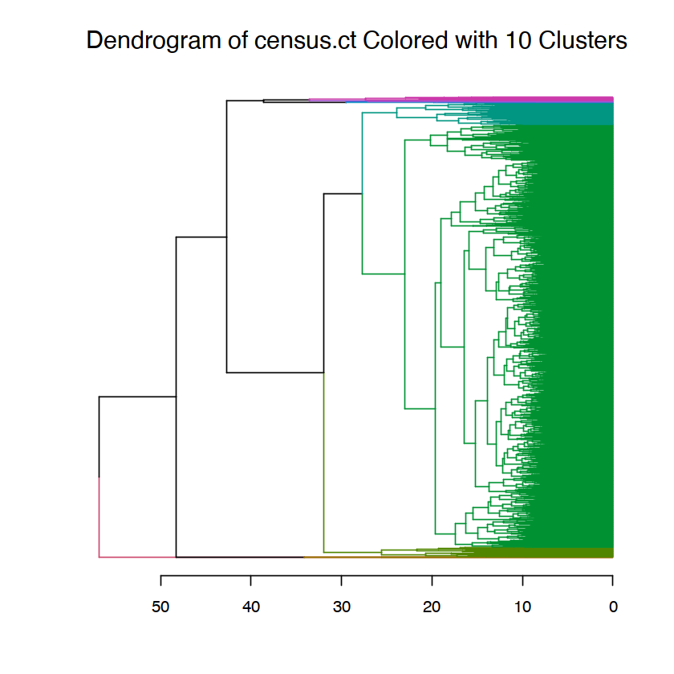

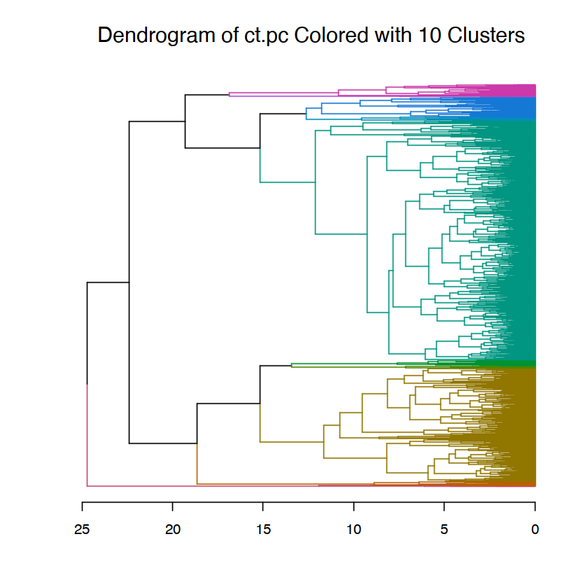

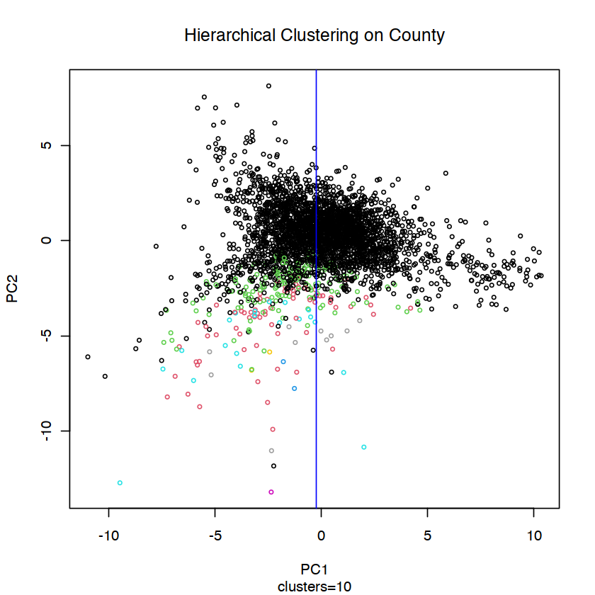

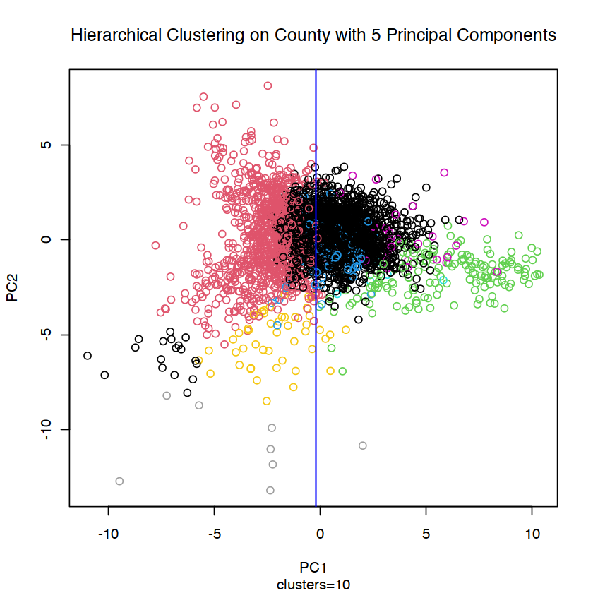

```r
ct_dist=dist(census.ct,method = "euclidean")
set.seed(4)

cluster=hclust(ct_dist^(1/4), method="complete")
dend.ct=as.dendrogram(cluster)
dend.ct=color_branches(dend.ct,k=10)
dend.ct=color_labels(dend.ct,k=10)
dend.ct=set(dend.ct,"labels_cex",0.85)
dend.ct=set_labels(dend.ct, labels=census.ct$Type[order.dendrogram(dend.ct)])

plot(dend.ct,horiz=T,main = "Dendrogram of census.ct Colored with 10 Clusters",cex.main=1.5)

ct.pc1 =(county_model$x[,1:5])
ct.dist=dist(ct.pc1,method = "euclidean")

cluster1=hclust(ct.dist, method="complete")
dend.ct=as.dendrogram(cluster1)
dend.ct=color_branches(dend.ct,k=10)
dend.ct=color_labels(dend.ct,k=10)
dend.ct=set(dend.ct,"labels_cex",0.85)
dend.ct=set_labels(dend.ct, labels=census.ct$Type[order.dendrogram(dend.ct)])
plot(dend.ct,horiz=T,main = "Dendrogram of ct.pc Colored with 10 Clusters",cex.main=1.5)

SM<-cutree(cluster,10)
SMclust<-SM[which(census.ct$County=="San Mateo")]

SM1<-cutree(cluster1,10)
SMclust1<-SM1[which(census.ct$County=="San Mateo")]


 plot(county_model$x, col = SM,  main="Hierarchical Clustering on County", sub="clusters=10", cex = .5)
  abline(v = ct.pc[SMclust,1], col = "blue")


 plot(ct.pc1 ,col=SM1,
      main="Hierarchical Clustering on County with 5 Principal Components", sub="clusters=10" )
 abline(v = ct.pc[SMclust1,], col = "blue")
```

## Classification

Our data is now ready for classification so we commence by pruning the tree to minimize misclassification error using generated folds for the cross-validation. We then visualize the trees before and after pruning and assess the training and test errors and save these to a *records* variable.

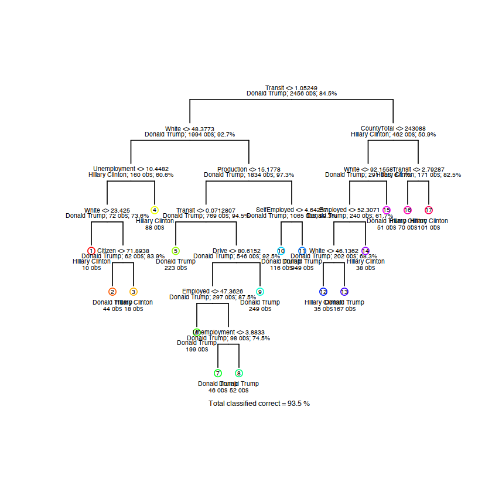

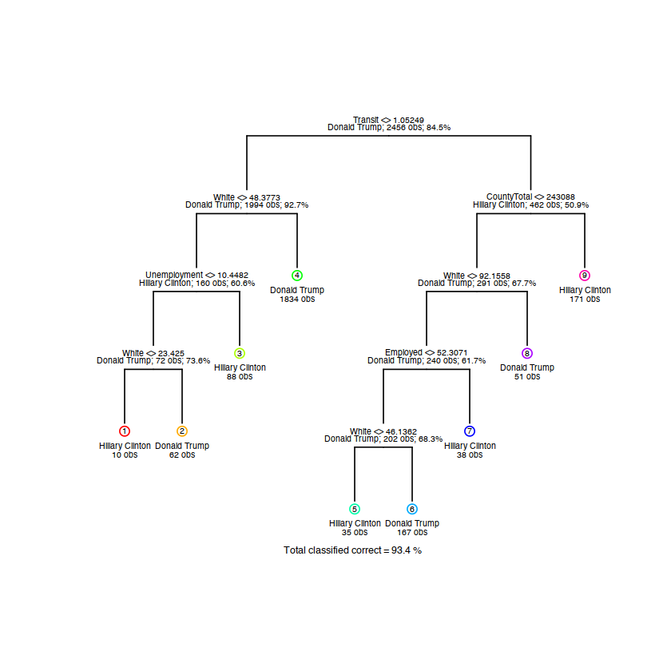

```r
tmpwinner <- county_winner %>% ungroup %>%
  mutate(state = state.name[match(state, state.abb)]) %>%               ## state abbreviations
  mutate_at(vars(state, county), tolower) %>%                           ## to all lowercase
  mutate(county = gsub(" county| columbia| city| parish", "", county))  ## remove suffixes
tmpcensus <- census.ct %>% mutate_at(vars(State, County), tolower)

election.cl <- tmpwinner %>%
  left_join(tmpcensus, by = c("state"="State", "county"="County")) %>%
  na.omit

## save meta information
election.meta <- election.cl %>% select(c(county, fips, state, votes, pct, total))

## save predictors and class labels
election.cl = election.cl %>% select(-c(county, fips, state, votes, pct, total))

set.seed(10)
n <- nrow(election.cl)
in.trn <- sample.int(n, 0.8*n)
trn.cl <- election.cl[ in.trn,]
tst.cl <- election.cl[-in.trn,]

set.seed(20)
nfold <- 10
folds <- sample(cut(1:nrow(trn.cl), breaks=nfold, labels=FALSE))

calc_error_rate = function(predicted.value, true.value){
  return(mean(true.value!=predicted.value))
}
records = matrix(NA, nrow=4, ncol=2)
colnames(records) = c("train.error","test.error")
rownames(records) = c("tree","logistic","lasso","Knn")


#Fit Tree model
tree=tree(candidate~.,data=trn.cl)
draw.tree(tree, nodeinfo = TRUE,cex=0.5)

set.seed(102)
# cross validation
cvtree=cv.tree(tree,FUN=prune.misclass, K=10,rand=folds)
#determine best size
best.size.cv=cvtree$size[max(which(cvtree$dev==min(cvtree$dev)))]


#Prune Tree to a tree with only 10 leaf nodes
prune=prune.tree(tree,best=best.size.cv, method = "misclass")
draw.tree(prune, nodeinfo = TRUE,cex=0.5)

#Error rate

#Training Error
records = matrix(NA, nrow=4, ncol=2)

set.seed(98)
pred.prune.train = predict(prune,trn.cl,type="class")
records[1,1]<-calc_error_rate(pred.prune.train, trn.cl$candidate)

#Test Error
pred.prune.test=predict(prune,tst.cl,type="class")
records[1,2]<-calc_error_rate(pred.prune.test, tst.cl$candidate)
```

## Prediction of winning candidate

```r
trn.cl$candidate <- factor(trn.cl$candidate, levels=c("Donald Trump", "Hillary Clinton"))
tst.cl$candidate <- factor(tst.cl$candidate, levels=c("Donald Trump", "Hillary Clinton"))
glm.fit=glm(candidate~.,data=trn.cl,family=binomial)

print(summary(glm.fit))

#Training Error
prob.training = round(predict(glm.fit, type="response"),digits=5)
trn.cl1 = trn.cl %>%
  mutate(predcand=as.factor(ifelse(prob.training<=0.5, "Donald Trump", "Hillary Clinton")))

records[2,1]<-calc_error_rate(trn.cl1$predcand,trn.cl$candidate)

#Test Error
prob.test = round(predict(glm.fit, tst.cl, type="response"),digits=5)
tst.cl1 = tst.cl %>%
  mutate(predcand=as.factor(ifelse(prob.test<=0.5, "Donald Trump", "Hillary Clinton")))

records[2,2]<-calc_error_rate(tst.cl1$predcand,tst.cl$candidate)
```

```
Call:
glm(formula = candidate ~ ., family = binomial, data = trn.cl)

Deviance Residuals:
    Min       1Q   Median       3Q      Max
-3.9948  -0.2600  -0.1104  -0.0399   3.5372

Coefficients:
                  Estimate Std. Error z value Pr(>|z|)
(Intercept)     -2.487e+01  9.452e+00  -2.631  0.00850 **
Men              9.589e-02  4.824e-02   1.988  0.04682 *
White           -1.689e-01  6.763e-02  -2.497  0.01253 *
Citizen          1.302e-01  2.796e-02   4.657 3.20e-06 ***
Income          -8.708e-05  2.729e-05  -3.192  0.00142 **
IncomeErr       -3.326e-06  6.365e-05  -0.052  0.95833
IncomePerCap     2.671e-04  6.699e-05   3.987 6.70e-05 ***
IncomePerCapErr -3.605e-04  1.715e-04  -2.102  0.03560 *
Poverty          4.741e-02  4.052e-02   1.170  0.24193
ChildPoverty    -1.582e-02  2.458e-02  -0.644  0.51971
Professional     2.802e-01  3.870e-02   7.240 4.48e-13 ***
Service          3.242e-01  4.758e-02   6.814 9.46e-12 ***
Office           7.590e-02  4.465e-02   1.700  0.08917 .
Production       1.668e-01  4.093e-02   4.076 4.58e-05 ***
Drive           -2.097e-01  4.617e-02  -4.542 5.58e-06 ***
Carpool         -1.736e-01  5.929e-02  -2.928  0.00342 **
Transit          7.578e-02  9.424e-02   0.804  0.42134
OtherTransp     -6.258e-02  9.503e-02  -0.659  0.51021
WorkAtHome      -1.657e-01  7.198e-02  -2.302  0.02133 *
MeanCommute      5.616e-02  2.422e-02   2.319  0.02039 *
Employed         2.056e-01  3.354e-02   6.132 8.69e-10 ***
PrivateWork      1.010e-01  2.189e-02   4.615 3.93e-06 ***
SelfEmployed     1.968e-02  4.678e-02   0.421  0.67394
FamilyWork      -8.873e-01  3.765e-01  -2.357  0.01844 *
Unemployment     2.073e-01  3.971e-02   5.219 1.80e-07 ***
Minority        -3.053e-02  6.509e-02  -0.469  0.63902
CountyTotal      3.511e-07  4.299e-07   0.817  0.41405
---
Signif. codes:  0 ‘***’ 0.001 ‘**’ 0.01 ‘*’ 0.05 ‘.’ 0.1 ‘ ’ 1

(Dispersion parameter for binomial family taken to be 1)

    Null deviance: 2119.56  on 2455  degrees of freedom
Residual deviance:  854.47  on 2429  degrees of freedom
AIC: 908.47

Number of Fisher Scoring iterations: 7
```